# Project Python Foundations: FoodHub Data Analysis

**Marks: 60**

### Context

The number of restaurants in New York is increasing day by day. Lots of students and busy professionals rely on those restaurants due to their hectic lifestyles. Online food delivery service is a great option for them. It provides them with good food from their favorite restaurants. A food aggregator company FoodHub offers access to multiple restaurants through a single smartphone app.

The app allows the restaurants to receive a direct online order from a customer. The app assigns a delivery person from the company to pick up the order after it is confirmed by the restaurant. The delivery person then uses the map to reach the restaurant and waits for the food package. Once the food package is handed over to the delivery person, he/she confirms the pick-up in the app and travels to the customer's location to deliver the food. The delivery person confirms the drop-off in the app after delivering the food package to the customer. The customer can rate the order in the app. The food aggregator earns money by collecting a fixed margin of the delivery order from the restaurants.

### Objective

The food aggregator company has stored the data of the different orders made by the registered customers in their online portal. They want to analyze the data to get a fair idea about the demand of different restaurants which will help them in enhancing their customer experience. Suppose you are hired as a Data Scientist in this company and the Data Science team has shared some of the key questions that need to be answered. Perform the data analysis to find answers to these questions that will help the company to improve the business.

### Data Description

The data contains the different data related to a food order. The detailed data dictionary is given below.

### Data Dictionary

- order_id: Unique ID of the order
- customer_id: ID of the customer who ordered the food
- restaurant_name: Name of the restaurant
- cuisine_type: Cuisine ordered by the customer
- cost: Cost of the order
- day_of_the_week: Indicates whether the order is placed on a weekday or weekend (The weekday is from Monday to Friday and the weekend is Saturday and Sunday)
- rating: Rating given by the customer out of 5
- food_preparation_time: Time (in minutes) taken by the restaurant to prepare the food. This is calculated by taking the difference between the timestamps of the restaurant's order confirmation and the delivery person's pick-up confirmation.
- delivery_time: Time (in minutes) taken by the delivery person to deliver the food package. This is calculated by taking the difference between the timestamps of the delivery person's pick-up confirmation and drop-off information

### Let us start by importing the required libraries

```python
# import libraries for data manipulation
import numpy as np
import pandas as pd
from scipy.stats import chi2_contingency  # Import the chi-squared test function


# import libraries for data visualization
import matplotlib.pyplot as plt
import seaborn as sns
```

### Understanding the structure of the data

```python
# uncomment and run the following lines for Google Colab
#from google.colab import drive
#drive.mount('/content/drive')
```

```python
# read the data
df = pd.read_csv('data/foodhub_order.csv')
# returns the first 5 rows
df.head()
```

|  | order_id | customer_id | restaurant_name | cuisine_type | cost_of_the_order | day_of_the_week | rating | food_preparation_time | delivery_time |
| --- | --- | --- | --- | --- | --- | --- | --- | --- | --- |
| 0 | 1477147 | 337525 | Hangawi | Korean | 30.75 | Weekend | Not given | 25 | 20 |
| 1 | 1477685 | 358141 | Blue Ribbon Sushi Izakaya | Japanese | 12.08 | Weekend | Not given | 25 | 23 |
| 2 | 1477070 | 66393 | Cafe Habana | Mexican | 12.23 | Weekday | 5 | 23 | 28 |
| 3 | 1477334 | 106968 | Blue Ribbon Fried Chicken | American | 29.20 | Weekend | 3 | 25 | 15 |
| 4 | 1478249 | 76942 | Dirty Bird to Go | American | 11.59 | Weekday | 4 | 25 | 24 |

#### Observations:

The DataFrame has 9 columns as mentioned in the Data Dictionary. Data in each row corresponds to the order placed by a customer.

### **Question 1:** How many rows and columns are present in the data? [0.5 mark]

```python
# Write your code here
# Write your code here
# Get the number of rows and columns
num_rows, num_columns = df.shape

# Print the results
print(f"Number of rows: {num_rows}")
print(f"Number of columns: {num_columns}")
```

```
Number of rows: 1898
Number of columns: 9
```

#### Observations:

there are 1898 rows and 9 columns in the dataset

### **Question 2:** What are the datatypes of the different columns in the dataset? (The info() function can be used) [0.5 mark]

```python
# Use info() to print a concise summary of the DataFrame
df.info()
print("--------------------------------------")
data_frame_columns = df.dtypes
print(f"Number of rows:\n {data_frame_columns}")
print("--------------------------------------")
```

```
<class 'pandas.core.frame.DataFrame'>
RangeIndex: 1898 entries, 0 to 1897
Data columns (total 9 columns):
 #   Column                 Non-Null Count  Dtype
---  ------                 --------------  -----
 0   order_id               1898 non-null   int64
 1   customer_id            1898 non-null   int64
 2   restaurant_name        1898 non-null   object
 3   cuisine_type           1898 non-null   object
 4   cost_of_the_order      1898 non-null   float64
 5   day_of_the_week        1898 non-null   object
 6   rating                 1898 non-null   object
 7   food_preparation_time  1898 non-null   int64
 8   delivery_time          1898 non-null   int64
dtypes: float64(1), int64(4), object(4)
memory usage: 133.6+ KB
--------------------------------------
Number of rows:
 order_id                   int64
customer_id                int64
restaurant_name           object
cuisine_type              object
cost_of_the_order        float64
day_of_the_week           object
rating                    object
food_preparation_time      int64
delivery_time              int64
dtype: object
--------------------------------------
```

#### Observations:

the data set is having mixed of numerical and Object types. interestingly rating should be number but I see it's object, which indicates some bad rating not string in rating colums which are not actually a rating.

### **Question 3:** Are there any missing values in the data? If yes, treat them using an appropriate method. [1 mark]

```python
# Write your code here
df.info()
```

```
<class 'pandas.core.frame.DataFrame'>
RangeIndex: 1898 entries, 0 to 1897
Data columns (total 9 columns):
 #   Column                 Non-Null Count  Dtype
---  ------                 --------------  -----
 0   order_id               1898 non-null   int64
 1   customer_id            1898 non-null   int64
 2   restaurant_name        1898 non-null   object
 3   cuisine_type           1898 non-null   object
 4   cost_of_the_order      1898 non-null   float64
 5   day_of_the_week        1898 non-null   object
 6   rating                 1898 non-null   object
 7   food_preparation_time  1898 non-null   int64
 8   delivery_time          1898 non-null   int64
dtypes: float64(1), int64(4), object(4)
memory usage: 133.6+ KB
```

#### Observations:

All the colums syas non null hence no missing values, however there could be undesired values, which might need some clean up later on.

### **Question 4:** Check the statistical summary of the data. What is the minimum, average, and maximum time it takes for food to be prepared once an order is placed? [2 marks]

```python
# Write your code here
df.describe()
```

|  | order_id | customer_id | cost_of_the_order | food_preparation_time | delivery_time |
| --- | --- | --- | --- | --- | --- |
| count | 1.898000e+03 | 1898.000000 | 1898.000000 | 1898.000000 | 1898.000000 |
| mean | 1.477496e+06 | 171168.478398 | 16.498851 | 27.371970 | 24.161749 |
| std | 5.480497e+02 | 113698.139743 | 7.483812 | 4.632481 | 4.972637 |
| min | 1.476547e+06 | 1311.000000 | 4.470000 | 20.000000 | 15.000000 |
| 25% | 1.477021e+06 | 77787.750000 | 12.080000 | 23.000000 | 20.000000 |
| 50% | 1.477496e+06 | 128600.000000 | 14.140000 | 27.000000 | 25.000000 |
| 75% | 1.477970e+06 | 270525.000000 | 22.297500 | 31.000000 | 28.000000 |
| max | 1.478444e+06 | 405334.000000 | 35.410000 | 35.000000 | 33.000000 |

#### Observations:

Some useful stats can be drawn from above table, like avg delivery time ~24 min min, avg food pef time ~27 min

### **Question 5:** How many orders are not rated? [1 mark]

```python
# Write the code here
order_not_rated = (df["rating"] ==  "Not given").sum()
print(f"no of order does not have rating: {order_not_rated}")
```

```
no of order does not have rating: 736
```

#### Observations:

no of order does not have rating: 736 which is ~38%

### Exploratory Data Analysis (EDA)

### **Question 6:** Explore all the variables and provide observations on their distributions. (Generally, histograms, boxplots, countplots, etc. are used for univariate exploration.) [9 marks]

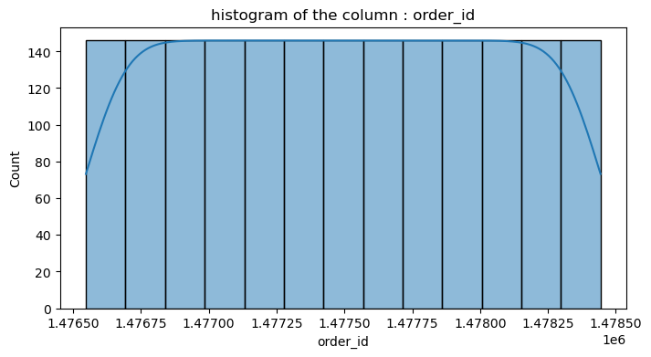

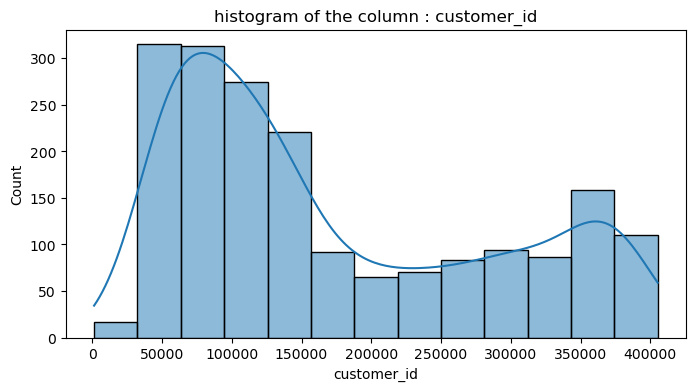

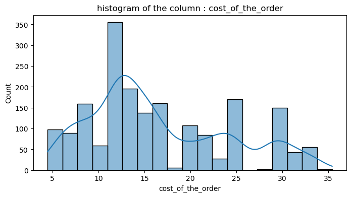

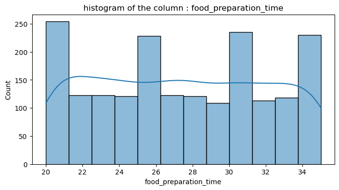

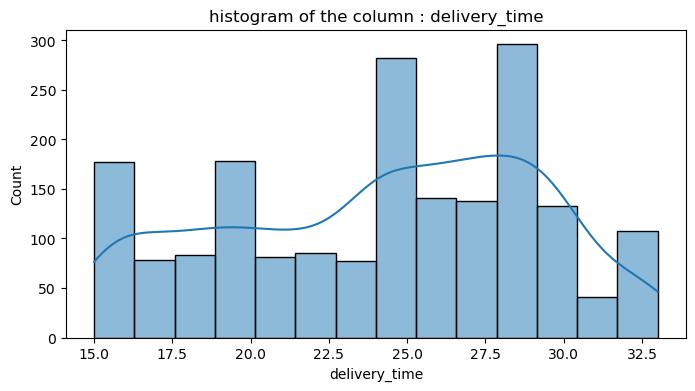

```python
# Write the code here
# Plot histograms for numeric variables
numeric_columns = df.select_dtypes(include=['int64', 'float64']).columns
for column in numeric_columns:
    plt.figure(figsize=(8,4))
    sns.histplot(df,  x = column, kde=True)
    plt.title(f"histogram of the column : {column}")
    plt.show()
```

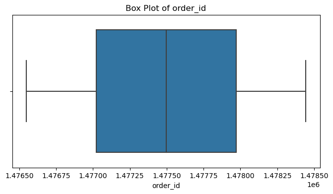

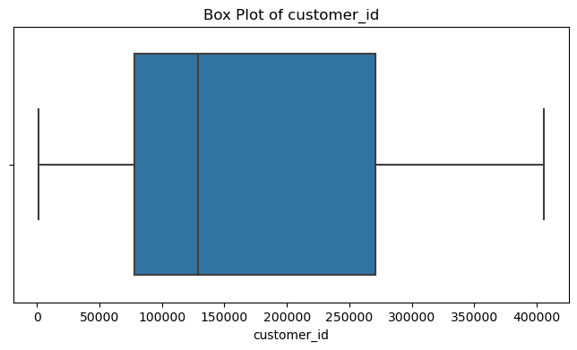

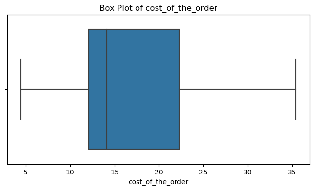

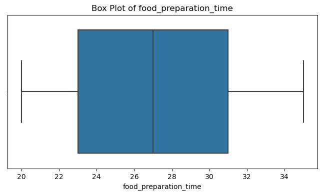

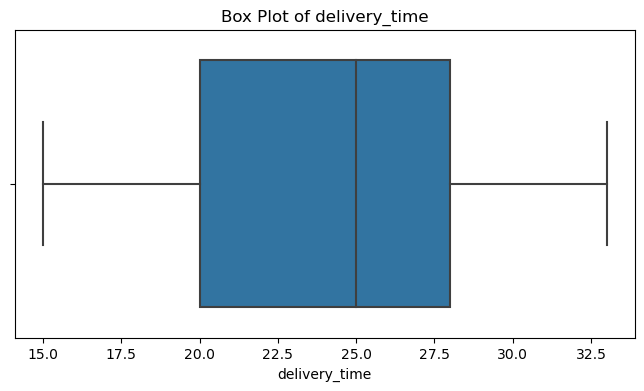

```python
# Plot box plots for numeric variables
for column in numeric_columns:
    plt.figure(figsize=(8, 4))
    sns.boxplot(data=df, x=column)
    plt.title(f'Box Plot of {column}')
    plt.show()
```

[figure not shown]

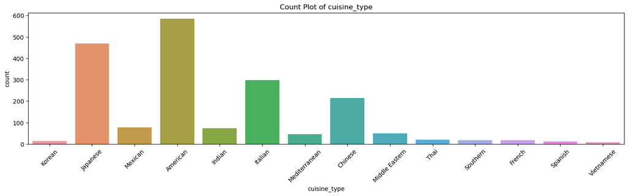

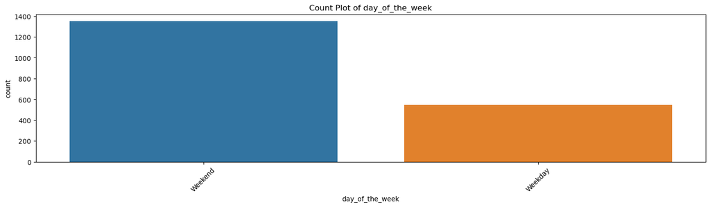

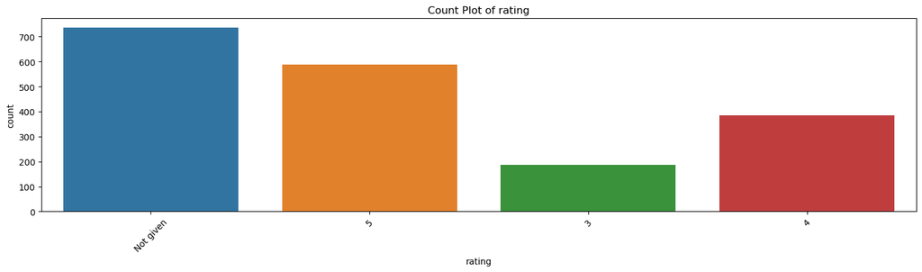

```python
# Plot count plots for categorical variables
categorical_columns = df.select_dtypes(include=['object']).columns
for column in categorical_columns:
    plt.figure(figsize=(18, 4))
    sns.countplot(data=df, x=column)
    plt.title(f'Count Plot of {column}')
    plt.xticks(rotation=45)  # Rotate x-axis labels for better readability
    plt.show()
```

*observation* ~ numerical columns like order_id, does not have much insights. ~ delivery_time, food_prep time shows useful insights

### **Question 7**: Which are the top 5 restaurants in terms of the number of orders received? [1 mark]

```python
# Write the code here
# Group the data by restaurant_name and count the number of orders for each restaurant
restaurant_order_counts = df['restaurant_name'].value_counts()
# Get the top 5 restaurants with the most orders
top_5_restaurants = restaurant_order_counts.head(5)
print("Top 5 Restaurants by Number of Orders:")
print(top_5_restaurants)
```

```
Top 5 Restaurants by Number of Orders:
Shake Shack                  219
The Meatball Shop            132
Blue Ribbon Sushi            119
Blue Ribbon Fried Chicken     96
Parm                          68
Name: restaurant_name, dtype: int64
```

#### Observations:

Top 5 Restaurants by Number of Orders: Shake Shack, The Meatball Shop, Blue Ribbon Sushi, Blue Ribbon Fried Chicken,parm

### **Question 8**: Which is the most popular cuisine on weekends? [1 mark]

```python
# Write the code here
#df.groupby('cuisine_type')['day_of_the_week' == 'Weekend']
weekend_orders = df[df['day_of_the_week'] == 'Weekend']
weekend_cuisine_counts = weekend_orders['cuisine_type'].value_counts()
weekend_cuisine_counts.head(1)
```

```
American    415
Name: cuisine_type, dtype: int64
```

#### Observations:

American is most popular cuisine over the weekend.

### **Question 9**: What percentage of the orders cost more than 20 dollars? [2 marks]

```python
# Write the code here
percentage_above_20 = (df['cost_of_the_order'] > 20).mean() * 100
percentage_above_20
```

```
29.24130663856691
```

#### Observations:

(df['cost_of_the_order'] > 20) will create a boolean search true/false, getting the mean() & multiplying with 100 will give % of order >20

### **Question 10**: What is the mean order delivery time? [1 mark]

```python
# Write the code here
mean_order_delivery_time = df['delivery_time'].mean()
print(f"mean order delivery time :{mean_order_delivery_time}")
```

```
mean order delivery time :24.161749209694417
```

#### Observations:

avg delivery time of order is ~24.16

### **Question 11:** The company has decided to give 20% discount vouchers to the top 3 most frequent customers. Find the IDs of these customers and the number of orders they placed. [1 mark]

```python
# Write the code here
# Count the number of orders placed by each customer
customer_order_counts = df['customer_id'].value_counts()
# Get the top 3 customers with the most orders
top_3_customers = customer_order_counts.head(3)
# Print the IDs and the number of orders for the top 3 customers
print("Top 3 Most Frequent Customers:")
print(top_3_customers)
```

```
Top 3 Most Frequent Customers:
52832    13
47440    10
83287     9
Name: customer_id, dtype: int64
```

#### Observations:

top 3 customers apparently places ~ 13, 10, 9 orders.

### **Question 12**: Perform a multivariate analysis to explore relationships between the important variables in the dataset. (It is a good idea to explore relations between numerical variables as well as relations between numerical and categorical variables) [10 marks]

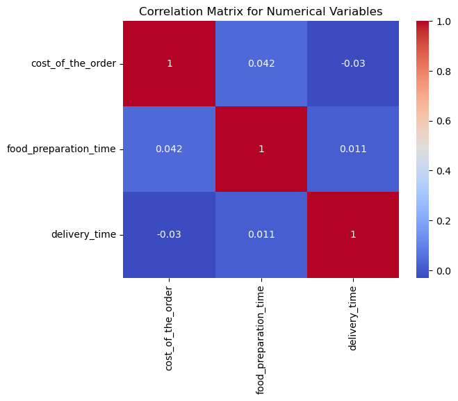

```python
# Write the code here
# Correlation Analysis for Numerical Variables
numerical_vars = ['cost_of_the_order', 'rating', 'food_preparation_time', 'delivery_time']
correlation_matrix = df[numerical_vars].corr()
sns.heatmap(correlation_matrix, annot=True, cmap='coolwarm')
plt.title("Correlation Matrix for Numerical Variables")
plt.show()
```

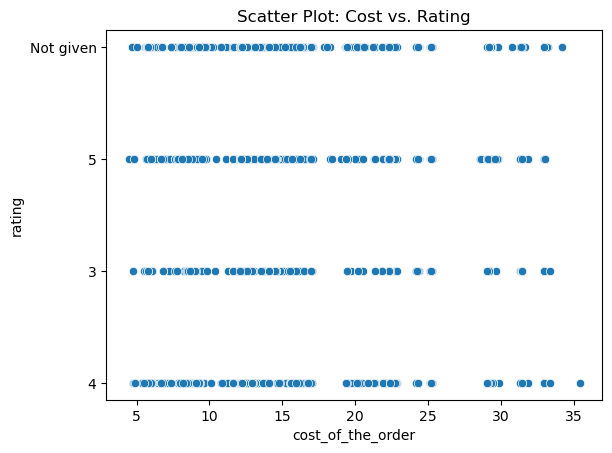

```python
# Scatter Plot between 'cost_of_the_order' and 'rating'
sns.scatterplot(x='cost_of_the_order', y='rating', data=df)
plt.title("Scatter Plot: Cost vs. Rating")
plt.show()
```

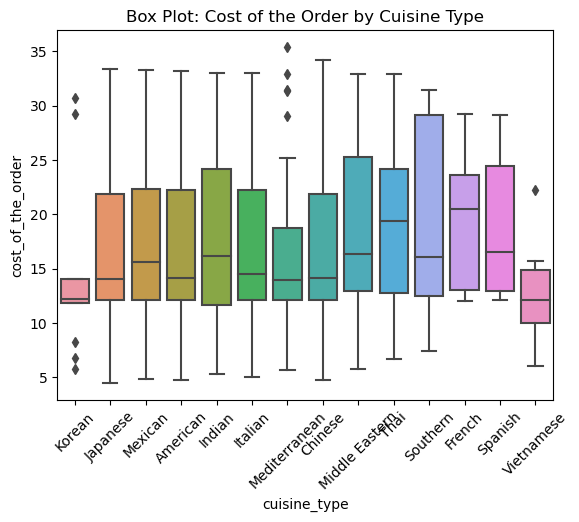

```python
# Box Plot of 'cost_of_the_order' by 'cuisine_type'
sns.boxplot(x='cuisine_type', y='cost_of_the_order', data=df)
plt.title("Box Plot: Cost of the Order by Cuisine Type")
plt.xticks(rotation=45)
plt.show()
```

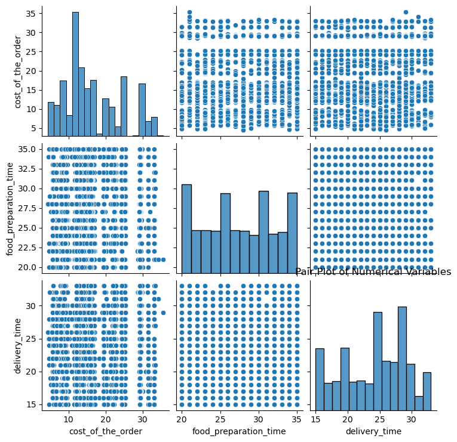

```python
# Pair Plot for Numerical Variables
sns.pairplot(df[numerical_vars])
plt.title("Pair Plot of Numerical Variables")
plt.show()
```

```python
# Chi-Square Test for 'cuisine_type' and 'day_of_the_week' (Categorical-Categorical)
contingency_table = pd.crosstab(df['cuisine_type'], df['day_of_the_week'])
chi2, p, _, _ = chi2_contingency(contingency_table)
print(f"Chi-Square Statistic: {chi2}")
print(f"P-value: {p}")
```

```
Chi-Square Statistic: 9.547288225517978
P-value: 0.7304685567606379
```

### **Question 13:** The company wants to provide a promotional offer in the advertisement of the restaurants. The condition to get the offer is that the restaurants must have a rating count of more than 50 and the average rating should be greater than 4. Find the restaurants fulfilling the criteria to get the promotional offer. [3 marks]

```python
# Convert 'rating' column to numeric, setting non-numeric values to NaN
df['rating'] = pd.to_numeric(df['rating'], errors='coerce')
restaurant_stats = df.groupby('restaurant_name')['rating'].agg(['mean', 'count'])
selected_restaurants = restaurant_stats[(restaurant_stats['mean'] > 4) & (restaurant_stats['count'] > 50)]
selected_restaurants
```

| restaurant_name | mean | count |
| --- | --- | --- |
| Blue Ribbon Fried Chicken | 4.328125 | 64 |
| Blue Ribbon Sushi | 4.219178 | 73 |
| Shake Shack | 4.278195 | 133 |
| The Meatball Shop | 4.511905 | 84 |

```python
mean_rating = df['rating'].apply(pd.to_numeric, errors='coerce').mean()
df['rating'] = df['rating'].replace('Not given', mean_rating)
restaurant_stats = df.groupby('restaurant_name')['rating'].agg(['mean', 'count'])
selected_restaurants = restaurant_stats[(restaurant_stats['mean'] > 4) & (restaurant_stats['count'] > 50)]
selected_restaurants
```

| restaurant_name | mean | count |
| --- | --- | --- |
| Blue Ribbon Fried Chicken | 4.328125 | 64 |
| Blue Ribbon Sushi | 4.219178 | 73 |
| Shake Shack | 4.278195 | 133 |
| The Meatball Shop | 4.511905 | 84 |

### **Question 14:** The company charges the restaurant 25% on the orders having cost greater than 20 dollars and 15% on the orders having cost greater than 5 dollars. Find the net revenue generated by the company across all orders. [3 marks]

```python
# Write the code here
cost_of_the_order_more_then_20 = df[df['cost_of_the_order'] > 20]
cost_of_the_order_more_then_20_total = (cost_of_the_order_more_then_20['cost_of_the_order'] * .25) .sum()

cost_of_the_order_between_5_and_15_total = (df[(df['cost_of_the_order'] > 5) & (df['cost_of_the_order'] < 20)]['cost_of_the_order']  * .15).sum()
total_revenue = (cost_of_the_order_more_then_20_total + cost_of_the_order_between_5_and_15_total)
print("Total revenue generated by the company: ${:.2f}".format(total_revenue))
```

```
Total revenue generated by the company: $6166.30
```

#### Observations:

Total revenue generated by the company: $6166.30

### **Question 15:** The company wants to analyze the total time required to deliver the food. What percentage of orders take more than 60 minutes to get delivered from the time the order is placed? (The food has to be prepared and then delivered.) [2 marks]

```python
# Write the code here
df['total_delivery_time'] = df['food_preparation_time'] + df['delivery_time']
percentage_orders_more_than_60_minutes = (df['total_delivery_time'] > 60).mean() * 100
print(f"Percentage of orders taking more than 60 minutes: {percentage_orders_more_than_60_minutes:.2f}%")
```

```
Percentage of orders taking more than 60 minutes: 10.54%
```

#### Observations:

Percentage of orders taking more than 60 minutes: 10.54%

### **Question 16:** The company wants to analyze the delivery time of the orders on weekdays and weekends. How does the mean delivery time vary during weekdays and weekends? [2 marks]

```python
# Write the code here
mean_delivery_time_by_day = df.groupby('day_of_the_week')['delivery_time'].mean()
print(mean_delivery_time_by_day)
```

```
day_of_the_week
Weekday    28.340037
Weekend    22.470022
Name: delivery_time, dtype: float64
```

### Recommendations:

- Promotional Offers: The company can offer promotional deals for restaurants with high ratings and a significant number of reviews. This will attract more *customers and enhance the customer experience.
- Cuisine-Specific Promotions: Identify the most popular cuisine types and offer promotions for restaurants specializing in those cuisines.
- Customer Engagement: Encourage customers to provide ratings and reviews by offering incentives or discounts for their next orders. This can help improve the overall quality of service and attract more customers.Also improve the no rating by proactively notify customer to submit reviews since ~38% are 'Not Given'
- Delivery Time Optimization: Analyze factors affecting delivery times, especially on weekdays, and take measures to ensure prompt and timely delivery.
- Cost-Effective Offers: The company should focus on offering discounts to restaurants with higher-cost orders, as this can attract more orders and generate additional revenue for the company.
- Feedback Loop: Establish a feedback system for customers and restaurant partners to address issues, make improvements, and adapt to changing preferences effectively.